# Analysing Sentences Backbone Communities

Published

November 6, 2025

```r
source(here::here("scripts", "paths_and_packages.R"))
p_load(see, backbone, kableExtra, DT)

# Loading Data
bert_df <- readRDS(file.path(
  data_path,
  "closest_sentences_0.01_rationality_score_filtered_with_embeddings.rds"
))
setDT(bert_df, key = "sentence_id")
bert_df <- bert_df[between(publication_year, 1900, 2019), ]

metadata <- read_rds(file.path(
  data_path,
  "full_metadata_journals_cleaned.rds"
)) %>%
  .[
    refined_sub_type == "research-article" & language == "eng",
    .(id, is_part_of, title, creator, publication_year, jstor_url = url)
  ] %>%
  .[order(publication_year)]

documents_cluster <- readRDS(file.path(
  data_path,
  "sentences_intertemporal_cluster.rds"
)) %>%
  left_join(select(bert_df, id, sentence, sentence_id, similarity)) %>%
  left_join(metadata) %>%
  arrange(sentence_id)

rm(metadata)

bert_df <- bert_df |>
  left_join(
    select(
      documents_cluster,
      sentence_id,
      backbone_community,
      window,
      kmean_cluster_id
    ),
    by = "sentence_id"
  )

backbone_network <- read_rds(file.path(
  data_path,
  "sentences_clusters_backbone_network.rds"
))

list_clusters <- documents_cluster %>%
  pull(backbone_community) %>%
  unique() |>
  sort()

results <- readRDS(file.path(data_path, "clustering_rational_sentences.rds"))

match_jstor_wos <- readRDS(here::here(data_path, "final_match.RDS")) %>%
  filter(!is.na(id_match_final)) %>%
  distinct(url_jstor = id_jstor, ID_Art = id_match_final) %>%
  mutate(
    id_jstor = str_extract(url_jstor, "\\/[0-9]+$") %>% str_remove(., "/"),
    ID_Art = as.character(ID_Art)
  ) %>%
  distinct(ID_Art, .keep_all = TRUE)
```

```r
# Naming clusters and tf-idf---------------------
setDT(documents_cluster)
unigrams <- documents_cluster[, .(
  sentence_id,
  sentence,
  window,
  kmean_cluster_id,
  backbone_community
)][, token := tokenizers::tokenize_words(sentence, lowercase = TRUE)][,
  -("sentence")
]
bigrams <- documents_cluster[, .(
  sentence_id,
  sentence,
  window,
  kmean_cluster_id,
  backbone_community
)][, token := tokenizers::tokenize_ngrams(sentence, n = 2, lowercase = TRUE)][,
  -("sentence")
]
tokens <- rbind(unigrams, bigrams)
tokens <- tokens[,
  .(token = unlist(token)),
  by = .(kmean_cluster_id, backbone_community, window)
]
tokens <- tokens[nchar(token) >= 2, ]
tokens <- tokens[, c("word_1", "word_2") := tstrsplit(token, " ")]

stop_words <- tidytext::stop_words$word %>%
  unique()
tokens <- tokens[
  # Remove any digits in either word
  !grepl("[0-9]", word_1) &
    (is.na(word_2) | !grepl("[0-9]", word_2)) &
    # Remove stopwords in either word
    !(word_1 %in% stop_words) &
    (is.na(word_2) | !(word_2 %in% stop_words))
]
tokens <- tokens[, .(kmean_cluster_id, backbone_community, window, token)]
tokens[, token := str_replace(token, " ", "_")]

tokens_count_kmean_cluster <- compute_tf_idf(
  tokens,
  token_col = "token",
  document_col = "kmean_cluster_id"
)
# Top tf-idf terms
top_terms_kmean_cluster <- tokens_count_kmean_cluster[order(-tf_idf)][
  absolute_tf > 20,
  head(.SD, 15),
  by = kmean_cluster_id
]

# Labels per decade
labels_kmean_cluster <- tokens_count_kmean_cluster[order(-tf_idf)][
  absolute_tf > 20,
  head(.SD, 5),
  by = kmean_cluster_id
]
labels_kmean_cluster <- labels_kmean_cluster[,
  .(label_kmean_cluster = paste0(token, collapse = ", ")),
  by = .(backbone_community, kmean_cluster_id)
]
labels_kmean_cluster[,
  label_kmean_cluster := paste0(backbone_community, "_", kmean_cluster_id, ": ", label_kmean_cluster) # we save the backbonne community number to see difference in top terms depending on kmean cluster
]

documents_cluster <- merge(
  documents_cluster,
  labels_kmean_cluster,
  all.x = TRUE,
  by = c("backbone_community", "kmean_cluster_id")
)
```

```r
# The strategy here is to calculate tf-idf at the window level, and then to average, to avoid giving too much weight to more recent windows.
tokens[,
  new_variable := str_c(
    backbone_community,
    window,
    sep = "--"
  )
]
tokens_count_window <- compute_tf_idf(
  tokens,
  token_col = "token",
  document_col = "new_variable"
)

tfidf_mean_community <- tokens_count_window[
  absolute_tf > 20,
  .(mean_tf_idf = mean(tf_idf)),
  by = .(token, backbone_community)
][order(-mean_tf_idf)]

# Top tf-idf terms
top_terms_cluster <- tfidf_mean_community[,
  head(.SD, 20),
  by = backbone_community
]

# Get top 4 tf-idf tokens per cluster
labels_backbone_community <- tfidf_mean_community[,
  head(.SD, 4),
  by = backbone_community
][, .(backbone_community, token)]
labels_backbone_community <- labels_backbone_community[,
  .(label_backbone_community = paste0(token, collapse = ", ")),
  by = backbone_community
]
labels_backbone_community[,
  label_backbone_community := paste0(
    str_extract(backbone_community, "\\d+$"),
    ": ",
    label_backbone_community
  )
]

documents_cluster <- merge(
  documents_cluster,
  labels_backbone_community,
  all.x = TRUE,
  by = "backbone_community"
)
```

```r
# Adding references
sentences_art <- documents_cluster %>%
  count(id, kmean_cluster_id, backbone_community) %>%
  inner_join(
    distinct(match_jstor_wos, id = id_jstor, ID_Art),
    relationship = "many-to-many"
  ) %>%
  mutate(ID_Art = as.integer(ID_Art)) %>%
  distinct(ID_Art, kmean_cluster_id, backbone_community, nb_sentence = n)

refs <- open_dataset(
  here::here(wos_data_path, "all_ref.parquet"),
  format = "parquet"
) %>%
  filter(ID_Art %in% unique(sentences_art$ID_Art)) %>%
  select(ID_Art, ItemID_Ref, Annee, Nom, Revue_Abbrege) %>%
  collect()

top_refs <- sentences_art %>%
  left_join(refs, by = "ID_Art", relationship = "many-to-many") %>%
  filter(ItemID_Ref != 0) %>%
  group_by(kmean_cluster_id, backbone_community, ItemID_Ref, nb_sentence) %>%
  summarise(absolute_cluster_cit = n(), .groups = "drop") %>%
  mutate(weighted_cluster_cit = absolute_cluster_cit * nb_sentence) %>%
  arrange(backbone_community, kmean_cluster_id, desc(weighted_cluster_cit)) %>%
  group_by(backbone_community, kmean_cluster_id) %>%
  slice_head(n = 20) %>%
  ungroup() %>%
  filter(weighted_cluster_cit > 1) %>%
  left_join(
    refs %>% distinct(ItemID_Ref, Nom, Annee, Revue_Abbrege),
    by = "ItemID_Ref",
    relationship = "many-to-many"
  ) %>%
  distinct(
    backbone_community,
    kmean_cluster_id,
    ItemID_Ref,
    absolute_cluster_cit,
    weighted_cluster_cit,
    .keep_all = TRUE
  ) %>%
  mutate(
    absolute_cit = sum(absolute_cluster_cit),
    all_sentences = sum(nb_sentence),
    weighted_cit = absolute_cit * all_sentences,
    .by = c(ItemID_Ref, backbone_community)
  )

top_refs_without_id <- sentences_art %>%
  left_join(refs, by = "ID_Art", relationship = "many-to-many") %>%
  filter(ItemID_Ref == 0 & Annee != 0 & Nom != "") %>%
  group_by(backbone_community, kmean_cluster_id, Nom, Annee) %>%
  mutate(
    absolute_cluster_cit = n(),
    weighted_cluster_cit = absolute_cluster_cit * nb_sentence
  ) %>%
  filter(weighted_cluster_cit > 1) %>%
  distinct(ID_Art, backbone_community, kmean_cluster_id, .keep_all = TRUE) %>%
  arrange(backbone_community, kmean_cluster_id, desc(weighted_cluster_cit)) %>%
  group_by(backbone_community, kmean_cluster_id) %>%
  slice_head(n = 20) %>%
  ungroup() %>%
  select(
    backbone_community,
    kmean_cluster_id,
    Nom,
    Annee,
    Revue_Abbrege,
    nb_sentence,
    absolute_cluster_cit,
    weighted_cluster_cit
  ) %>%
  distinct(
    backbone_community,
    kmean_cluster_id,
    Nom,
    Annee,
    .keep_all = TRUE
  ) %>%
  mutate(
    absolute_cit = sum(absolute_cluster_cit),
    all_sentences = sum(nb_sentence),
    weighted_cit = absolute_cit * all_sentences,
    .by = c(Nom, Annee, Revue_Abbrege, backbone_community)
  )

rm(refs)
```

```r
# Here, we find the sentences the closest to "rational" and "rationality" per kmean cluster
# We would then be able to extract the closest per backbone community later on
top_sentences_rationality <- bert_df %>%
  select(
    id,
    sentence_id,
    sentence,
    similarity,
    publication_year,
    window,
    backbone_community,
    kmean_cluster_id
  ) %>%
  group_by(kmean_cluster_id) %>%
  slice_max(similarity, n = 20) %>%
  ungroup() %>%
  mutate(similarity = round(similarity, 3))
```

```r
# Here, we find the sentences the closest to the centroid of the k-mean cluster. This has been calculated
# directly from the loop in clustering_sbert_closest_sentences.R and saved in documents_cluster
top_sentences_kmean_cluster_centroid <- documents_cluster |>
  slice_min(distance_to_centroid, n = 10, by = kmean_cluster_id) |>
  select(
    id,
    sentence_id,
    sentence,
    distance_to_centroid,
    publication_year,
    window,
    backbone_community,
    kmean_cluster_id
  )
```

```r
# Here, we want to find the closest sentences to the centroid of the backbone communities. This implies
# calculating the centroid of each backbone community first, and then calculating cosine similarity between
# each sentenc embeddings and the centroid.

# Convert to data.table
bert_df_for_mat <- copy(bert_df)

# Expand bert_embedding_concat list into separate columns
# Assume each embedding is length 3072
bert_df_for_mat <- bert_df_for_mat[, as.data.table(do.call(rbind, embedding))]
bert_df_for_mat$backbone_community <- bert_df$backbone_community

# Calculate mean of each dimension by backbone_community
cluster_centroids <- bert_df_for_mat[,
  lapply(.SD, mean),
  by = backbone_community
]

# Ensure embedding columns are correctly selected
embedding_cols <- setdiff(names(bert_df_for_mat), "backbone_community")

# Build paragraph matrix with sentence_id as row names
# sentences_mat <- as.matrix(bert_df_for_mat[, ..embedding_cols])
# rownames(sentences_mat) <- bert_df$sentence_id

# Build centroid matrix with backbone_community as row names
centroid_mat <- as.matrix(cluster_centroids[, ..embedding_cols])
rownames(centroid_mat) <- cluster_centroids$backbone_community

# Get the list of clusters
clusters <- unique(bert_df_for_mat$backbone_community)
bert_df_for_mat$sentence_id <- bert_df$sentence_id

# Set how many top sentences you want
top_n <- 20

top_sentences_backbone_community_centroid <- map_dfr(
  clusters,
  function(cluster) {
    # Filter sentences for this cluster
    cluster_sentences <- bert_df_for_mat[backbone_community == cluster]

    # Extract the centroid for this cluster
    centroid_vec <- centroid_mat[cluster, , drop = FALSE]

    # Calculate cosine similarity
    cluster_mat <- as.matrix(cluster_sentences[, ..embedding_cols])
    rownames(cluster_mat) <- cluster_sentences$sentence_id

    sim_vec <- text2vec::sim2(
      x = cluster_mat,
      y = centroid_vec,
      method = "cosine",
      norm = "l2"
    )[, 1]

    # Get top N most similar sentences
    top_idx <- order(sim_vec, decreasing = TRUE)[1:min(top_n, length(sim_vec))]

    data.table(
      backbone_community = cluster,
      sentence_id = names(sim_vec)[top_idx],
      similarity = sim_vec[top_idx],
      rank = 1:length(top_idx)
    )
  }
)
top_sentences_backbone_community_centroid[, sentence_id := as.integer(sentence_id)]

rm(bert_df, bert_df_for_mat)
```

```r
set.seed(89)
palette_colors <- c(see::see_colors()[1:14],
                    see::oi_colors()[1:7],
                    scico::scico(n = 6, palette = "roma")) %>%
  sample()

nb_clusters <- documents_cluster %>%
  pull(backbone_community) %>%
  unique() %>%
  length
if(nb_clusters > length(palette_colors)) cli_alert_danger("The number of clusters exceed the number of available colors in the palette. Please extend the palette.")
cluster_colors <- palette_colors[1:nb_clusters]
```

# General Description of the Method

We start from JSTOR economics articles, split them into sentences, and embed each sentence with Sentence-BERT. To target discourse about the future, we build year-specific “query” embeddings for *rational* and *rationality* using a 5-year sliding window, which limits present-day bias in meanings. For every year, we compute cosine similarity between each sentence and that year’s query vector and retain the top 1% most similar sentences.

Within each decade, we cluster the selected sentences with k-means and compute cluster centroids. We then form intertemporal clusters: we start from the matrix of cosine similarity between clusters centroids. Then, we use backbone statistical disparity function to find the most significant links between clusters. Finally, we build a network connecting k-mean clusters with these links and identify communities thanks to Leiden algorithm.

We label backbone community (the meta-clusters) and k-mean clusters with high-TF-IDF unigrams and bigrams and summarize them with indicators: centroid-closest sentences, “future(s)” exemplars, temporal distributions, and top contributing articles. The report is structured along backbone communities, but we also provide disaggregation by k-mean clusters within each backbone community.

The next visualisations shows the overall network of kmean clusters connected by similarity links, coloured by backbone community.

```r
centroids <- map(1:length(results), ~ pluck(results, ., "centroids")) %>%
  bind_rows %>%
  mutate(cluster_original_id = 1:n())

# Calculate cosine similarity between all centroids
centroid_matrix <- centroids %>%
  select(-.cluster, -window, -cluster_original_id) %>%
  as.matrix()
cosine_sim <- lsa::cosine(t(centroid_matrix))

window_levels <- documents_cluster %>%
  pull(window) %>%
  unique() %>%
  sort()

# Finding proximity between backbone communities based on their centroids
# extract node table from g
nodes_tbl <- backbone_network %>%
  activate("nodes") %>%
  as_tibble(.name_repair = "minimal") |>
  mutate(x = as.integer(factor(window, levels = window_levels)))

# feature columns in `centroids` (exclude meta cols)
feat_cols <- setdiff(
  names(centroids),
  c(".cluster", "window", "cluster_original_id")
)

# 2) average centroid features per intertemporal community (new_cluster)
comm_centroids <- centroids %>%
  mutate(cluster_id = 1:n()) %>%
  left_join(nodes_tbl %>% select(cluster_id, community), by = "cluster_id") %>%
  group_by(community) %>%
  summarise(
    across(all_of(feat_cols), ~ mean(.x, na.rm = TRUE)),
    .groups = "drop"
  )

# 3) hierarchical clustering on scaled community-centroid matrix
mat <- comm_centroids %>% select(-community) %>% as.matrix()
mat_scaled <- scale(mat) # scale so features comparable
d <- dist(mat_scaled, method = "euclidean")
hc <- hclust(d, method = "average")

# 4) order communities along the dendrogram
comm_levels <- comm_centroids$community[hc$order]

# 5) build a smooth palette so adjacent communities are visually similar
names(cluster_colors) <- comm_levels
```

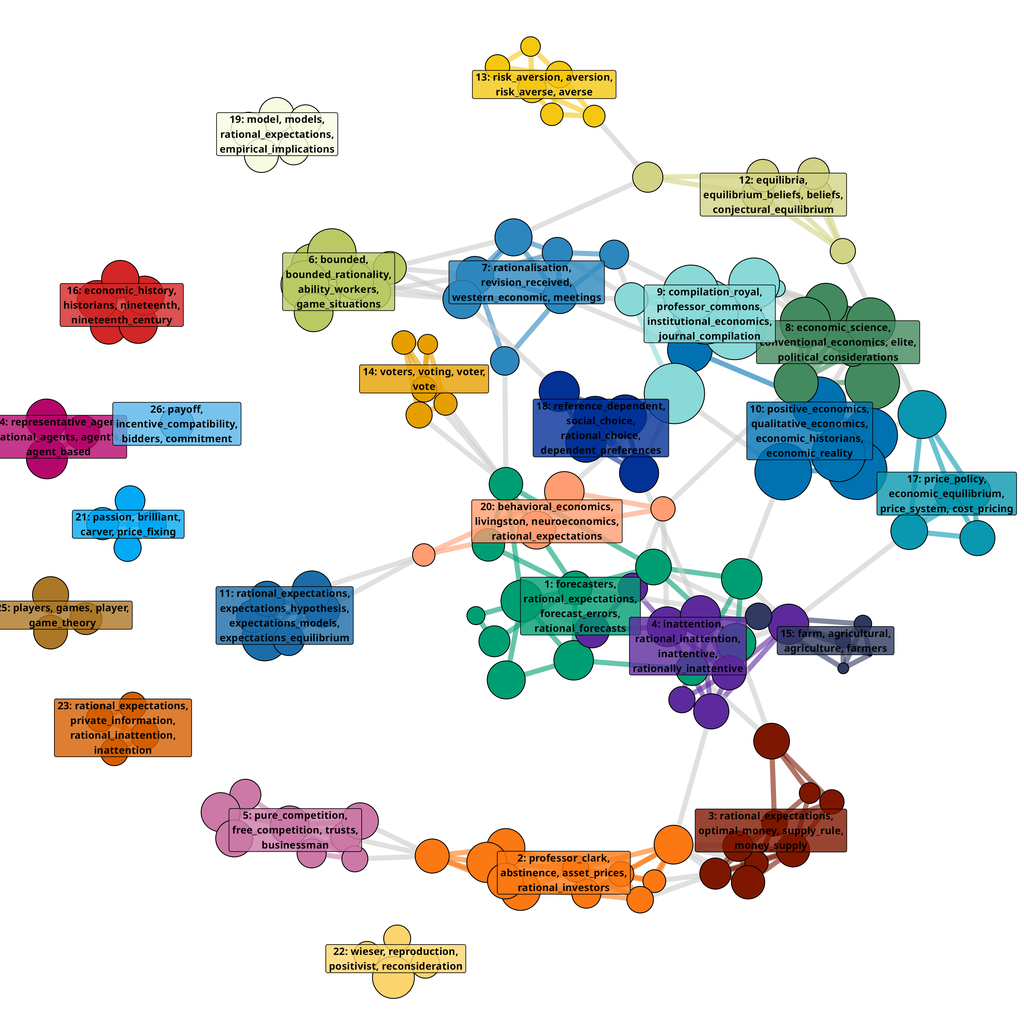

```r
documents_cluster[, size_window := .N, by = window]
documents_cluster[,
  proportion_kmean_cluster := .N / size_window,
  by = kmean_cluster_id
]
backbone_network <- backbone_network %>%
  activate("nodes") %>%
  left_join(
    documents_cluster %>%
      distinct(
        cluster_id = kmean_cluster_id,
        backbone_community,
        label_kmean_cluster,
        label_backbone_community,
        proportion_kmean_cluster
      ),
    by = "cluster_id"
  )

backbone_network <- backbone_network %>%
  activate("edges") %>%
  mutate(
    community_from = .N()[["community"]][from],
    community_to = .N()[["community"]][to],
    edge_community = if_else(
      community_from == community_to,
      community_from,
      NA_character_
    ),
    edge_community = factor(edge_community, levels = comm_levels)
  )

# compute layout and community centroids
set.seed(89)
layout <- ggraph::create_layout(backbone_network, layout = "fr")

community_average <- layout %>%
  as_tibble() %>%
  group_by(community) %>%
  summarize(
    x = mean(x, na.rm = TRUE),
    y = mean(y, na.rm = TRUE),
    .groups = "drop"
  ) %>%
  left_join(
    layout %>% as_tibble() %>% distinct(community, label_backbone_community),
    by = "community"
  )

# plot: edges coloured by edge_community when endpoints share same community, otherwise grey
backbone_network_plot <- ggraph(layout
) +
  geom_edge_link(
    aes(colour = edge_community),
    alpha = 0.6,
    width = 2,
    show.legend = FALSE
  ) +
  geom_node_point(
    aes(fill = community, size = proportion_kmean_cluster),
    show.legend = FALSE,
    shape = 21
  ) +
  geom_label(
    data = community_average,
    aes(
      x = x,
      y = y,
      label = str_wrap(label_backbone_community, 30),
      fill = community
    ),
    size = 3,
    fontface = "bold",
    alpha = 0.8,
    show.legend = FALSE
  ) +
  scale_edge_width(range = c(0.2, 3)) +
  scale_size_continuous(range = c(1, 25)) +
  labs(edge_width = "Avg similarity") +
  scale_edge_color_manual(values = cluster_colors, na.value = "grey80") +
  scale_fill_manual(values = cluster_colors) +
  theme_void()

ggsave(
  here("pictures", "backbone_communities_network.png"),
  backbone_network_plot,
  units = "cm",
  width = 30,
  height = 30,
  dpi = 300
)

knitr::include_graphics(here("pictures", "backbone_communities_network.png"))
```

```r
p_load(ggiraph)

set.seed(89)
backbone_network_ggiraph_plot <- ggraph(layout) +
  geom_edge_link(
    aes(colour = edge_community),
    alpha = 0.6,
    width = 2,
    show.legend = FALSE
  ) +
  # interactive node points: tooltip = label_kmean_cluster, data_id = cluster_id
  geom_point_interactive(
    aes(
      x = x,
      y = y,
      fill = community,
      size = proportion_kmean_cluster,
      tooltip = str_c(
        label_kmean_cluster,
        "\nPeriod:",
        window,
        "\nProportion of sentences in window: ",
        round(proportion_kmean_cluster * 100, 2),
        "%"
      ),
      data_id = cluster_id
    ),
    show.legend = FALSE,
    shape = 21
  ) +
  scale_size_continuous(range = c(1, 20)) +
  labs(edge_width = "Avg similarity") +
  scale_edge_color_manual(values = cluster_colors, na.value = "grey80") +
  scale_fill_manual(values = cluster_colors) +
  theme_void()

# create interactive girafe object with sensible hover/tooltip styling
girafe_obj <- ggiraph::girafe(
  ggobj = backbone_network_ggiraph_plot,
  width_svg = 16,
  height_svg = 10,
  options = list(
    ggiraph::opts_selection(type = "single"),
    ggiraph::opts_zoom(min = 1, max = 12), # wheel to zoom, drag to pan
    ggiraph::opts_toolbar(position = "topright")
  )
)

girafe_obj
```

[interactive chart not shown]

The next visualisation takes the same nodes and edges but repositions the nodes in a temporal layout, with time on the x-axis and communities stacked on the y-axis. It allows to see how backbone communities evolve over time.

```r
# per-window equally spaced y to avoid overlap
nodes_pos <- nodes_tbl %>%
  group_by(window) %>%
  arrange(desc(community), .by_group = TRUE) %>%
  mutate(
    n_in_window = n(),
    y = ifelse(n_in_window == 1, 0, seq(-1, 1, length.out = n_in_window))
  ) %>%
  ungroup()

# distribute nodes vertically within each (community, window) cell to avoid overlap
# compute per-(community,x) offsets without calling seq() on a vector
# compute required band per community (max nodes in any x for that community)
comm_band <- nodes_pos %>%
  mutate(community = factor(community, levels = comm_levels)) %>%
  group_by(community, x) %>%
  summarise(n_in_cell = n(), .groups = "drop") %>%
  group_by(community) %>%
  summarise(
    max_in_column = max(n_in_cell, na.rm = TRUE),
    .groups = "drop"
  ) %>%
  arrange(community) %>%
  mutate(
    max_in_column = pmax(max_in_column, 1L),
    pad = 0.7, # vertical padding between community bands
    band = max_in_column + pad # total vertical band height for the community
  ) %>%
  mutate(
    baseline = cumsum(lag(band, default = 0)) + band / 2 # center y for each community band
  ) %>%
  select(community, band, baseline)

# assign nodes within their community/x band
nodes_pos <- nodes_pos %>%
  mutate(community = factor(community, levels = comm_levels)) %>%
  left_join(comm_band, by = "community") %>%
  group_by(community, x) %>%
  arrange(window, cluster_id, .by_group = TRUE) %>%
  mutate(
    n_in_cell = n(),
    # centered offsets inside the community band; works for n_in_cell == 1 as well
    offset = (row_number() - 0.5) * band / n_in_cell - band / 2,
    y = baseline + offset
  ) %>%
  ungroup() %>%
  select(cluster_id, x, y, community)

# join positions into the graph nodes (match keys exactly)
temporal_backbone_network <- backbone_network %>%
  activate("nodes") %>%
  left_join(nodes_pos, by = c("cluster_id", "community"))

# compute label positions for communities (uses comm_band and layout from above)
community_label_positions <- comm_band %>%
  left_join(
    layout %>% as_tibble() %>% distinct(community, label_backbone_community),
    by = "community"
  ) %>%
  arrange(match(community, comm_levels)) %>%
  mutate(label = str_wrap(label_backbone_community, 40))

temporal_network_plot <- ggraph(
  temporal_backbone_network,
  layout = "manual",
  x = x,
  y = y
) +
  geom_edge_link(
    aes(colour = edge_community),
    alpha = 0.5,
    show.legend = FALSE,
    width = 2
  ) +
  geom_label(
    aes(x = x, y = y, label = cluster_id, fill = community, size = proportion_kmean_cluster),
    label.padding = unit(0.12, "lines"),
    show.legend = FALSE,
    alpha = 0.9
  ) +
  scale_fill_manual(values = cluster_colors) +
  scale_edge_color_manual(values = cluster_colors, na.value = "grey80") +
  scale_x_continuous(
    breaks = seq_along(window_levels),
    labels = window_levels
  ) +
  # y axis showing community labels at their baseline positions
  scale_y_continuous(
    breaks = community_label_positions$baseline,
    labels = community_label_positions$label,
    expand = expansion(add = c(1, 0.8))
  ) +
  scale_size_continuous(range = c(3, 10)) +
  labs(x = NULL, y = NULL) +
  theme_minimal() +
  theme(
    panel.grid = element_blank(),
    axis.title.y = element_blank(),
    axis.text.y = element_text(size = 8, hjust = 1),
    axis.ticks.y = element_line(color = "grey50"),
    axis.line.y = element_line(color = "grey50"),
    axis.line.x = element_line(color = "grey50"),
    axis.ticks.x = element_line(color = "grey50"),
    axis.text.x = element_text(angle = 45, hjust = 1, vjust = 1, size = 9)
  )

ggsave(
  here("pictures", "temporal_network_plot.png"),
  temporal_network_plot,
  units = "cm",
  width = 30,
  height = 30,
  dpi = 300
)
```

```r
temporal_network_ggiraph_plot <- ggraph(
  temporal_backbone_network,
  layout = "manual",
  x = x,
  y = y
) +
  geom_edge_link(
    aes(colour = edge_community),
    alpha = 0.5,
    show.legend = FALSE
  ) +
  geom_point_interactive(
    aes(
      x = x,
      y = y,
      fill = community,
      size = proportion_kmean_cluster,
      tooltip = str_c(
        label_kmean_cluster,
        "\nPeriod:",
        window,
        "\nProportion of sentences in window: ",
        round(proportion_kmean_cluster * 100, 2),
        "%"
      ),
      data_id = cluster_id
    ),
    show.legend = FALSE,
    shape = 21,
    alpha = 0.9
  ) +
  scale_fill_manual(values = cluster_colors) +
  scale_edge_color_manual(values = cluster_colors, na.value = "grey80") +
  scale_x_continuous(
    breaks = seq_along(window_levels),
    labels = window_levels
  ) +
  # y axis showing community labels at their baseline positions
  scale_y_continuous(
    breaks = community_label_positions$baseline,
    labels = community_label_positions$label,
    expand = expansion(add = c(0.9, 0.9))
  ) +
  scale_size_continuous(range = c(2, 15)) +
  labs(x = NULL, y = NULL) +
  theme_minimal() +
  theme(
    panel.grid = element_blank(),
    axis.title.y = element_blank(),
    axis.text.y = element_text(size = 10, hjust = 1),
    axis.ticks.y = element_line(color = "grey50"),
    axis.line.y = element_line(color = "grey50"),
    axis.line.x = element_line(color = "grey50"),
    axis.ticks.x = element_line(color = "grey50"),
    axis.text.x = element_text(angle = 45, hjust = 1, vjust = 1, size = 9)
  )

# create interactive girafe object with sensible hover/tooltip styling
girafe_obj_time <- ggiraph::girafe(
  ggobj = temporal_network_ggiraph_plot,
  width_svg = 16,
  height_svg = 10,
  options = list(
    ggiraph::opts_selection(type = "single"),
    opts_tooltip(use_fill = TRUE),
    ggiraph::opts_zoom(min = 1, max = 12), # wheel to zoom, drag to pan
    ggiraph::opts_toolbar(position = "topright")
  )
)

girafe_obj_time
```

[interactive chart not shown]

## Description of the clusters: a reader’s guide

A series of indicators are produced for each clusters. Here are some explanations on how to read them.

### Header summary

**Note**

**What this shows**: size, time span, and main sources of the cluster.  
**How to read**:  
- **Sentences and share**: number of sentences in this cluster and its share of all analysed sentences.  
- **Period**: first and last window where this cluster appears.  
- **Recurring authors/journals**: most frequent contributors by sentence count.  
**Notes**: counts are sentence-level. Long papers can contribute many sentences.

### Top TF-IDF terms describing the community

**Tip**

**What this shows**: words or two-word phrases most specific to this intertemporal backbone community over the full period, in comparison to all other backbone communities.  
**How to read**: higher TF-IDF = greater within-cluster distinctiveness. Compare terms within this table.  
**Use**: quick topic fingerprint.  
**Caution**: This is not an “absolute” TF-IDF: to take into account the fact that more recent periods have more sentences, we average TF-IDF calculated at the window level.

### Top TF-IDF terms by kmean cluster

**Tip**

**What this shows**: the kmean cluster’s distinctive vocabulary.  
**How to read**: compare kmean clusters within the same backbone community to see terms that appear or fade.  
**Use**: detect shifts in focus, methods, or cases across time, as well as diversity within a backbone community.

### Distribution of sentences over time

**Note**

**What this shows**: yearly counts of sentences in this cluster.  
**How to read**: bars = activity level. Peaks = years with more writing on this theme.  
**Caution**: absolute counts, not shares. Later years may have more total publishing.

### Closest sentences from “rationality” and “rational” embeddings within the backbone community

**Note**

**What this shows**: sentences that have the highest cosine similarity with the “rational”/“rationality” embeddings  
**How to read**: examples of how this community talks about the future.  
**Caution**: ranked by the proximity with “rational”/“rationality” embeddings, not by the proximity with the centroid of the cluster (i.e. the average point in the cluster).

### Closest sentences to the backbone community centroid

**Note**

**What this shows**: sentences most representative of the backbone community’s core meaning.  
**How to read**: scan to grasp the cluster’s center. These sentences help to grasp what’s the cluster is about, but not necessarily how it talks about the future. **Caution**: this has been calculated by averaging the embeddings of all sentences in the backbone community, and then finding the sentences closest to this centroid. May be biased towards more recent periods when the community grew over time.

### Closest sentences to the kmean cluster centroids

**Tip**

**What this shows**: centroid-closest sentences split by window.  
**How to read**: compare phrasing across clusters to see stability or change, as well as diversity in the community. **Caution**: this has been calculated by calculating the distance of each sentence to the centroid of its kmean cluster. Here, we look at the lowest values (low distance) rather than highest values (high similarity).

### Top articles (most sentences) of the backbone community

**Note**

**What this shows**: works contributing the most sentences to this cluster.  
**Columns**: **Number sentences** and **Work Similarity**.  
— **Number sentences**: volume contributed by the work.  
— **Word Similarity**: mean of the cosine similarity to “rationality”/“rational” for that work’s sentences in this cluster.  
**How to read**: Most representative articles of the cluster. Worth clicking on the link to see more about what the article is about. Often a good way to understand how it talks about rationality.

### Top articles (most sentences) of each kmean cluster

**Note**

**What this shows**: same as above, but split by kmean cluster.  
**How to read**: see which articles contribute to which kmean clusters within the backbone community

### Most cited references in the backbone community

**Note**

**What this shows**: the references most often cited by the articles that contribute sentences to this community.

**Columns**  
- **First Author / Year / Journal**: metadata from the reference list.  
- **Citation by article**: number of *distinct articles in this cluster* that cite the reference.  
- **Citation by sentence**: **Citation by article** weighted by how many sentences those citing articles contribute to the cluster (higher = the reference is cited by more central articles in this cluster).

**How to read**: prefer **Citation by sentence** to identify anchors of the cluster; use **Citation by article** to see breadth of citing articles.

**Caveats**  
- The second table lists references *without stable IDs*. This helps recovering books but may be inaccurate.  
- Weighting captures cluster centrality of the *citing articles*, not the number of in-text mentions.  
- Abbreviated journal names may vary.

### Most cited references in each kmean clusters

**Tip**

**What this shows**: decade-level leaders by the same two indicators. **How to read**: compare decades and clusters in same decate to see which references anchor the community at different times.

### Column legend

- **Sentence**: quoted sentence.
- **Title**: clickable article title.
- **Year**: publication year.
- **Journal**: outlet.
- **Authors**: as listed.
- **Words Similarity**: cosine similarity to the embeddings of “rational”/“rationality”.
- **Centroid Similarity**: cosine similarity to the cluster’s centroid.
- **Distance to centroid**: distance to the kmean cluster’s centroid.
- **Number sentences**: sentences from that work in this cluster.

### General cautions

- Similarity values lie in [0,1]. Near-top differences can still matter.
- TF-IDF is comparative within this dataset.
- All counts reflect the top-1% sentences set used here.

# Description of the Clusters

```r
for (cluster in list_clusters) {
  cluster_data <- documents_cluster %>%
    filter(backbone_community == !!cluster) %>%
    mutate(title = glue("<a href='{jstor_url}' target='_blank'>{title}</a>"))
  cluster_name <- cluster_data %>%
    pull(label_backbone_community) %>%
    unique

  # extracting the first year and last year of the community
  window <- c(
    first(unique(cluster_data$window)) %>% str_extract("^\\d{4}"),
    last(unique(cluster_data$window)) %>% str_extract("\\d{4}$")
  )

  ################ Beginning of the template ######################
  cat(sprintf("  \n## Intertemporal cluster _%s_ \n\n", cluster_name))

  ############# General Info ##################
  cat(paste0(
    "  \nThe cluster gathers ",
    length(unique(cluster_data$sentence_id)),
    " sentences from our corpus. It represents ",
    round(
      length(unique(cluster_data$sentence_id)) /
        length(unique(documents_cluster$sentence_id)) *
        100,
      2
    ),
    "% of all the sentences selected over the whole period.\n"
  ))

  cat(paste0(
    "\nThe community exists from ",
    window[1],
    " to ",
    window[2],
    ". \n\n"
  ))

  recurring_authors <- cluster_data %>%
    select(creator, id) %>%
    unnest(creator) %>%
    add_count(creator, name = "nb_sentences") %>%
    distinct(creator, id, nb_sentences) %>%
    add_count(creator, name = "nb_articles") %>%
    distinct(creator, nb_sentences, nb_articles) %>%
    slice_max(order_by = nb_sentences, n = 10)
  cat(paste0(
    "The most recurring authors are ",
    paste0(
      recurring_authors$creator,
      " (",
      recurring_authors$nb_sentences,
      " sentences; ",
      recurring_authors$nb_articles,
      " articles)",
      collapse = ", "
    ),
    ".\n\n"
  ))

  recurring_journals <- cluster_data %>%
    select(is_part_of, id) %>%
    add_count(is_part_of, name = "nb_sentences") %>%
    distinct(is_part_of, id, nb_sentences) %>%
    add_count(is_part_of, name = "nb_articles") %>%
    distinct(is_part_of, nb_sentences, nb_articles) %>%
    slice_max(order_by = nb_sentences, n = 5)
  cat(paste0(
    "The most recurring journals are ",
    paste0(
      recurring_journals$is_part_of,
      " (",
      recurring_journals$nb_sentences,
      " sentences; ",
      recurring_journals$nb_articles,
      " articles)",
      collapse = ", "
    ),
    ".\n\n"
  ))

  ############# TF-IDF ##################
  cat("\n### Top TF-IDF terms describing the community\n\n")
  # Extracting top terms in general and for window
  top_terms_cluster %>%
    filter(backbone_community == !!cluster) %>%
    select(token, mean_tf_idf) %>%
    kbl(col.names = c("Token", "TF-IDF")) %>%
    kable_styling(
      bootstrap_options = c("striped", "condensed"),
      font_size = 15
    ) %>%
    print()

  if (length(unique(cluster_data$window)) > 1) {
    cat(
      "\n### Top TF-IDF terms describing the different k-means clusters\n\n"
    )

    for (kmean in unique(cluster_data$kmean_cluster_id)) {
      cat(
        glue(
          "#### Top terms {cluster_data[kmean_cluster_id == kmean,]$label_kmean_cluster |> unique()} ({cluster_data[kmean_cluster_id == kmean,]$window |> unique()})\n\n"
        ),
        sep = ""
      )

      top_terms_kmean_cluster %>%
        filter(kmean_cluster_id == kmean) %>%
        select(token, tf_idf) %>%
        kbl(col.names = c("Token", "TF-IDF")) %>%
        kable_styling(
          bootstrap_options = c("striped", "condensed"),
          font_size = 11
        ) %>%
        print()
    }
  }

  ############# Distribution sentences ##################
  cat("\n### Distribution of sentences over time \n\n")

  plot(
    cluster_data %>%
      count(publication_year) %>%
      ggplot(aes(x = publication_year, y = n)) +
      geom_bar(stat = "identity") +
      scale_x_continuous(expand = c(0.01, 0), n.breaks = 10) +
      scale_y_continuous(expand = c(0.01, 0)) +
      theme_light(base_size = 20) +
      labs(y = "Number of sentences", x = NULL, title = NULL)
  )

  ####### Top Sentences ###################
  top_sentences_rationality_filtered <- top_sentences_rationality %>%
    filter(backbone_community == !!cluster) %>%
    left_join(select(
      cluster_data,
      title,
      is_part_of,
      creator,
      jstor_url,
      sentence_id
    )) %>%
    mutate(title = glue("<a href='{jstor_url}' target='_blank'>{title}</a>"))

  top_sentences_kmean_cluster_centroid_filtered <- top_sentences_kmean_cluster_centroid %>%
    filter(backbone_community == !!cluster) %>%
    left_join(
      select(
        cluster_data,
        title,
        is_part_of,
        creator,
        sentence_id,
        jstor_url
      ),
      by = "sentence_id"
    ) %>%
    mutate(title = glue("<a href='{jstor_url}' target='_blank'>{title}</a>"))

  top_sentences_backbone_community_centroid_filtered <- top_sentences_backbone_community_centroid %>%
    filter(backbone_community == !!cluster) %>%
    left_join(
      select(
        cluster_data,
        title,
        publication_year,
        is_part_of,
        creator,
        sentence_id,
        sentence,
        jstor_url
      ),
      by = "sentence_id"
    ) %>%
    mutate(title = glue("<a href='{jstor_url}' target='_blank'>{title}</a>"))

  ############# Top sentences rationality ##################
  cat("\n\n")
  cat(
    "\n### Closest sentence from 'rational' and 'rationality' of the backbone community\n\n"
  )

  top_sentences_rationality_filtered %>%
    slice_max(similarity, n = 20, by = backbone_community) %>%
    select(
      sentence,
      title,
      publication_year,
      is_part_of,
      creator,
      similarity
    ) %>%
    kbl(
      escape = FALSE,
      col.names = c(
        "Sentence",
        "Title",
        "Year",
        "Journal",
        "Authors",
        "Words Similarity"
      )
    ) %>%
    kable_styling(
      bootstrap_options = c("striped", "condensed"),
      font_size = 12
    ) %>%
    column_spec(2, "3.5cm") %>%
    print()

  ############# Top sentences centroid ##################
  cat("\n### Closest sentences of the backbone community's centroid\n\n")
```

```r
  top_sentences_backbone_community_centroid_filtered %>%
    slice_max(similarity, n = 15) %>%
    select(
      sentence,
      title,
      publication_year,
      is_part_of,
      creator,
      similarity
    ) %>%
    kbl(
      escape = FALSE,
      col.names = c(
        "Sentence",
        "Title",
        "Year",
        "Journal",
        "Authors",
        "Centroid Similarity"
      )
    ) %>%
    kable_styling(
      bootstrap_options = c("striped", "condensed"),
      font_size = 13
    ) %>%
    column_spec(2, "3.5cm") %>%
    print()

  if (length(unique(cluster_data$kmean_cluster_id)) > 1) {
    cat(
      "\n### Closest sentences of each kmean cluster's centroid composing the backbone community\n\n"
    )

    for (kmean in unique(cluster_data$kmean_cluster_id)) {
      cat(
        glue(
          "#### Top terms {cluster_data[kmean_cluster_id == kmean,]$label_kmean_cluster |> unique()} ({cluster_data[kmean_cluster_id == kmean,]$window |> unique()})\n\n"
        ),
        sep = ""
      )

      top_sentences_kmean_cluster_centroid_filtered %>%
        filter(kmean_cluster_id == !!kmean) %>%
        slice_min(distance_to_centroid, n = 5) %>%
        select(
          sentence,
          title,
          publication_year,
          is_part_of,
          creator,
          distance_to_centroid
        ) %>%
        kbl(
          escape = FALSE,
          col.names = c(
            "Sentence",
            "Title",
            "Year",
            "Journal",
            "Authors",
            "Distance to Centroid"
          )
        ) %>%
        kable_styling(
          bootstrap_options = c("striped", "condensed"),
          font_size = 12
        ) %>%
        column_spec(2, "3.5cm") %>%
        print()
    }
  }

  ############# Top articles ##################
  cat("\n### Top articles (most sentences) of the backbone cluster\n\n")
  # Extracting top terms in general and for window
  cluster_data %>%
    mutate(
      mean_similarity = mean(similarity) %>% round(3),
      n = n(),
      .by = id
    ) %>%
    distinct(
      title,
      publication_year,
      is_part_of,
      creator,
      n,
      mean_similarity
    ) %>%
    slice_max(n, n = 15, with_ties = FALSE) %>%
    kbl(
      escape = FALSE,
      col.names = c(
        "Title",
        "Year",
        "Journal",
        "Authors",
        "Number sentences",
        "Words Similarity"
      )
    ) %>%
    kable_styling(
      bootstrap_options = c("striped", "condensed"),
      font_size = 13
    ) %>%
    print()

  if (length(unique(cluster_data$kmean_cluster_id)) > 1) {
    cat(
      "\n### Top articles (most sentences) of the cluster for each time window{.panel-tabset}\n\n"
    )

    for (kmean in unique(cluster_data$kmean_cluster_id)) {
      cat(
        glue(
          "#### Top articles for {cluster_data[kmean_cluster_id == kmean,]$label_kmean_cluster |> unique()} ({cluster_data[kmean_cluster_id == kmean,]$window |> unique()})\n\n"
        ),
        sep = ""
      )

      cluster_data %>%
        filter(kmean_cluster_id == !!kmean) %>%
        mutate(
          mean_similarity = mean(similarity) %>% round(3),
          n = n(),
          .by = id
        ) %>%
        distinct(
          title,
          publication_year,
          is_part_of,
          creator,
          n,
          mean_similarity
        ) %>%
        slice_max(n, n = 10, with_ties = FALSE) %>%
        kbl(
          escape = FALSE,
          col.names = c(
            "Title",
            "Year",
            "Journal",
            "Authors",
            "Number sentences",
            "Words Similarity"
          )
        ) %>%
        kable_styling(
          bootstrap_options = c("striped", "condensed"),
          font_size = 13
        ) %>%
        print()
    }
  }

  ############## Top References ##################
  cat("\n### Most cited references in the backbone community\n\n")

  top_refs %>%
    filter(backbone_community == cluster) %>%
    distinct(Nom, Annee, Revue_Abbrege, absolute_cit, weighted_cit) %>%
    filter(absolute_cit > 1) |>
    slice_max(weighted_cit, n = 15, with_ties = FALSE) %>%
    kbl(
      escape = FALSE,
      col.names = c(
        "First Author",
        "Year",
        "Journal",
        "Citation by article",
        "Citation by sentence"
      )
    ) %>%
    kable_styling(
      bootstrap_options = c("striped", "condensed"),
      font_size = 12
    ) %>%
    print()

  top_refs_without_id %>%
    filter(backbone_community == cluster) %>%
    distinct(Nom, Annee, Revue_Abbrege, absolute_cit, weighted_cit) %>%
    filter(absolute_cit > 1) |>
    slice_max(weighted_cit, n = 15, with_ties = FALSE) %>%
    kbl(
      escape = FALSE,
      col.names = c(
        "First Author",
        "Year",
        "Journal",
        "Citation by article",
        "Citation by sentence"
      )
    ) %>%
    kable_styling(
      bootstrap_options = c("striped", "condensed"),
      font_size = 12
    ) %>%
    print()

  if (length(unique(cluster_data$kmean_cluster_id)) > 1) {
    cat("\n### Most cited references per kmean clusters\n\n")

    for (kmean in unique(cluster_data$kmean_cluster_id)) {
      top_ref_cluster <- top_refs %>%
        filter(backbone_community == cluster, kmean_cluster_id == kmean) %>%
        distinct(
          Nom,
          Annee,
          Revue_Abbrege,
          absolute_cluster_cit,
          weighted_cluster_cit
        ) %>%
        slice_max(weighted_cluster_cit, n = 10, with_ties = FALSE)

      top_ref_without_id_cluster <- top_refs_without_id %>%
        filter(backbone_community == cluster, kmean_cluster_id == kmean) %>%
        distinct(
          Nom,
          Annee,
          Revue_Abbrege,
          absolute_cluster_cit,
          weighted_cluster_cit
        ) %>%
        slice_max(weighted_cluster_cit, n = 10, with_ties = FALSE)

      if (nrow(top_ref_cluster) != 0 | nrow(top_ref_without_id_cluster) != 0) {
        cat(
          glue(
            "#### Top references {cluster_data[kmean_cluster_id == kmean,]$label_kmean_cluster |> unique()} ({cluster_data[kmean_cluster_id == kmean,]$window |> unique()})\n\n"
          ),
          sep = ""
        )
        if (nrow(top_ref_cluster) > 0) {
          top_ref_cluster %>%
            kbl(
              escape = FALSE,
              col.names = c(
                "First Author",
                "Year",
                "Journal",
                "Citation by article",
                "Citation by sentence"
              )
            ) %>%
            kable_styling(
              bootstrap_options = c("striped", "condensed"),
              font_size = 12
            ) %>%
            print()
        }
```

```r
        if (nrow(top_ref_without_id_cluster) > 0) {
          top_ref_without_id_cluster %>%
            kbl(
              escape = FALSE,
              col.names = c(
                "First Author",
                "Year",
                "Journal",
                "Citation by article",
                "Citation by sentence"
              )
            ) %>%
            kable_styling(
              bootstrap_options = c("striped", "condensed"),
              font_size = 12
            ) %>%
            print()
        }
      }
    }
  }
}
```

## Intertemporal cluster *1: forecasters, rational_expectations, forecast_errors, rational_forecasts*

The cluster gathers 7621 sentences from our corpus. It represents 4.71% of all the sentences selected over the whole period.

The community exists from 1900 to 1999.

The most recurring authors are Frank H. Knight (121 sentences; 38 articles), Talcott Parsons (62 sentences; 9 articles), David E. Runkle (49 sentences; 4 articles), Michael P. Keane (39 sentences; 3 articles), Walton H. Hamilton (35 sentences; 10 articles), E. J. Mishan (33 sentences; 11 articles), Pami Dua (30 sentences; 3 articles), Wesley C. Mitchell (29 sentences; 9 articles), Roy Batchelor (27 sentences; 2 articles), H. J. Davenport (26 sentences; 12 articles), Oskar Lange (26 sentences; 5 articles).

The most recurring journals are The American Economic Review (1156 sentences; 695 articles), Journal of Political Economy (777 sentences; 427 articles), The Quarterly Journal of Economics (767 sentences; 373 articles), The Economic Journal (639 sentences; 348 articles), Economica (368 sentences; 193 articles).

### Top TF-IDF terms describing the community

| Token | TF-IDF |
| --- | --- |
| forecasters | 0.0056151 |
| rational_expectations | 0.0041630 |
| forecast_errors | 0.0028768 |
| rational_forecasts | 0.0025530 |
| forecast | 0.0023621 |
| forecast_error | 0.0023398 |
| forecasts | 0.0022899 |
| rational_forecast | 0.0020560 |
| forecast_rationality | 0.0018958 |
| optimum_allocation | 0.0014798 |
| form_rationality | 0.0014786 |
| futures | 0.0012992 |
| weak_form | 0.0012610 |
| laborer | 0.0012205 |
| time_series | 0.0011454 |
| workmen | 0.0010875 |
| rationality_tests | 0.0010637 |
| rationalisation | 0.0010470 |
| capitalistic | 0.0010208 |
| policy_action | 0.0010065 |

### Top TF-IDF terms describing the different k-means clusters

#### Top terms 1_9: enjoyment, social_economics, civilization, prosperity, subsistence (1900-1919)

| Token | TF-IDF |
| --- | --- |
| enjoyment | 0.0019905 |
| social_economics | 0.0019123 |
| civilization | 0.0015613 |
| prosperity | 0.0015395 |
| subsistence | 0.0014757 |
| religion | 0.0012902 |
| free_competition | 0.0010969 |
| happiness | 0.0010337 |
| evils | 0.0009945 |
| trusts | 0.0009845 |
| wasteful | 0.0009738 |
| speculator | 0.0009531 |
| nation | 0.0009444 |
| largest | 0.0009056 |
| beauty | 0.0008954 |

#### Top terms 1_17: laborer, laborers, workmen, employer, wages (1900-1919)

| Token | TF-IDF |
| --- | --- |
| laborer | 0.0091226 |
| laborers | 0.0056100 |
| workmen | 0.0055830 |
| employer | 0.0034779 |
| wages | 0.0032257 |
| employers | 0.0031515 |
| labor | 0.0015132 |
| remuneration | 0.0014960 |
| pain | 0.0014921 |
| torrens | 0.0014661 |
| industrial | 0.0013825 |
| subsistence | 0.0013766 |
| occupations | 0.0011937 |
| outlays | 0.0011694 |
| rent | 0.0011049 |

#### Top terms 1_28: rationalisation, productive_capacity, cotton, industries, productive_resources (1920-1939)

| Token | TF-IDF |
| --- | --- |
| rationalisation | 0.0032201 |
| productive_capacity | 0.0017503 |
| cotton | 0.0015256 |
| industries | 0.0014718 |
| productive_resources | 0.0014026 |
| employments | 0.0013627 |
| real_costs | 0.0011485 |
| industrial | 0.0011370 |
| productive_process | 0.0010002 |
| employer | 0.0009535 |
| industry | 0.0009428 |
| manufacture | 0.0009084 |
| productive | 0.0009016 |
| machinery | 0.0008916 |
| technical_progress | 0.0008751 |

#### Top terms 1_30: capitalistic, capitalism, collectivist, capitalist, socialist (1920-1939)

| Token | TF-IDF |
| --- | --- |
| capitalistic | 0.0045791 |
| capitalism | 0.0025691 |
| collectivist | 0.0020214 |
| capitalist | 0.0017825 |
| socialist | 0.0017554 |
| social_control | 0.0016502 |
| socialistic | 0.0016273 |
| economic_planning | 0.0016068 |
| collectivism | 0.0014271 |
| modern_capitalism | 0.0012474 |
| sombart | 0.0011804 |
| professor_mises | 0.0011769 |
| socialists | 0.0011417 |
| bourgeois | 0.0010820 |
| private_property | 0.0009518 |

#### Top terms 1_34: planning, economic_planning, governmental, planned, social_policy (1940-1949)

| Token | TF-IDF |
| --- | --- |
| planning | 0.0032021 |
| economic_planning | 0.0029553 |
| governmental | 0.0015031 |
| planned | 0.0014255 |
| social_policy | 0.0014118 |
| planned_economy | 0.0013281 |
| public_policy | 0.0012617 |
| administrative | 0.0010392 |
| scarce_resources | 0.0009342 |
| central_planning | 0.0008798 |
| national_economy | 0.0008627 |
| free_society | 0.0008471 |
| professor_hayek | 0.0007980 |
| legislation | 0.0007441 |
| machinery | 0.0007274 |

#### Top terms 1_45: private_enterprise, enterprise_system, free_enterprise, capitalistic, liberty (1940-1949)

| Token | TF-IDF |
| --- | --- |
| private_enterprise | 0.0032965 |
| enterprise_system | 0.0028836 |
| free_enterprise | 0.0027541 |
| capitalistic | 0.0022030 |
| liberty | 0.0021028 |
| capitalism | 0.0021012 |
| democracy | 0.0020079 |
| enterprise | 0.0019943 |
| freedom | 0.0017053 |
| collectivism | 0.0016478 |
| free_society | 0.0014863 |
| economic_freedom | 0.0014699 |
| socialist | 0.0013820 |
| capitalist | 0.0012863 |
| socialism | 0.0012787 |

#### Top terms 1_48: planning, optimum_allocation, economic_planning, allocation, resource_allocation (1950-1959)

| Token | TF-IDF |
| --- | --- |
| planning | 0.0023304 |
| optimum_allocation | 0.0021104 |
| economic_planning | 0.0020647 |
| allocation | 0.0016080 |
| resource_allocation | 0.0015973 |
| resource | 0.0015121 |
| scarce_resources | 0.0014359 |
| scarce | 0.0014211 |
| economic_development | 0.0014042 |
| scarcity | 0.0013844 |
| planners | 0.0013479 |
| water | 0.0011513 |
| central_planning | 0.0011064 |
| resources | 0.0009858 |
| underdeveloped | 0.0009317 |

#### Top terms 1_66: planning, economic_planning, planners, optimum_allocation, resource_allocation (1960-1969)

| Token | TF-IDF |
| --- | --- |
| planning | 0.0040728 |
| economic_planning | 0.0029365 |
| planners | 0.0028102 |
| optimum_allocation | 0.0027941 |
| resource_allocation | 0.0027143 |
| allocation | 0.0026179 |
| enterprises | 0.0015115 |
| resource | 0.0013234 |
| planner | 0.0013035 |
| rational_allocation | 0.0012986 |
| planned | 0.0012411 |
| external_diseconomies | 0.0012236 |
| scarce_resources | 0.0012200 |
| planned_economy | 0.0011924 |
| commands | 0.0011505 |

#### Top terms 1_71: economic_development, industrial_production, underdeveloped, economic_growth, technical_progress (1960-1969)

| Token | TF-IDF |
| --- | --- |
| economic_development | 0.0022074 |
| industrial_production | 0.0016673 |
| underdeveloped | 0.0016180 |
| economic_growth | 0.0012244 |
| technical_progress | 0.0011315 |
| production_function | 0.0008533 |
| productive_factors | 0.0007888 |
| soviet | 0.0007779 |
| external_economies | 0.0007721 |
| technological | 0.0007661 |
| productivity | 0.0007592 |
| production_functions | 0.0007536 |
| developed_countries | 0.0007531 |
| diseconomies | 0.0007378 |
| factor_prices | 0.0007055 |

#### Top terms 1_92: policy_implications, economic_policy, policy_makers, optimal_policy, optimal (1970-1979)

| Token | TF-IDF |
| --- | --- |
| policy_implications | 0.0025357 |
| economic_policy | 0.0020102 |
| policy_makers | 0.0017113 |
| optimal_policy | 0.0012574 |
| optimal | 0.0012547 |
| policy_action | 0.0010844 |
| makers | 0.0010307 |
| rational_expectations | 0.0010148 |
| alternative_policies | 0.0009606 |
| optimal_control | 0.0009366 |
| policy_decisions | 0.0008928 |
| discretionary | 0.0008452 |
| policy_objectives | 0.0008350 |
| policy_actions | 0.0007937 |
| rational_policy | 0.0007937 |

#### Top terms 1_96: rational_expectations, forecasts, forecast, expectations, forecasting (1980-1989)

| Token | TF-IDF |
| --- | --- |
| rational_expectations | 0.0074733 |
| forecasts | 0.0063837 |
| forecast | 0.0042954 |
| expectations | 0.0042218 |
| forecasting | 0.0030641 |
| perfect_foresight | 0.0028953 |
| futures | 0.0021188 |
| agents | 0.0017229 |
| rational_forecasts | 0.0016626 |
| forecast_errors | 0.0016480 |
| future_prices | 0.0014811 |
| forecast_error | 0.0013537 |
| model | 0.0013479 |
| foresight | 0.0013272 |
| price_expectations | 0.0013174 |

#### Top terms 1_115: forecasts, forecasters, forecast, rational_expectations, forecast_errors (1990-1999)

| Token | TF-IDF |
| --- | --- |
| forecasts | 0.0136064 |
| forecasters | 0.0112322 |
| forecast | 0.0106751 |
| rational_expectations | 0.0081502 |
| forecast_errors | 0.0046132 |
| forecasting | 0.0044109 |
| rational_forecasts | 0.0037941 |
| forecast_rationality | 0.0037437 |
| forecast_error | 0.0035946 |
| expectations | 0.0033334 |
| perfect_foresight | 0.0033130 |
| rational_forecast | 0.0031728 |
| rationality_tests | 0.0021536 |
| foresight | 0.0020097 |
| tests | 0.0019267 |

### Distribution of sentences over time

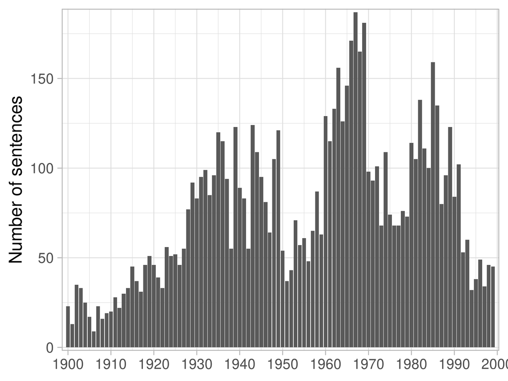

### Closest sentence from ‘rational’ and ‘rationality’ of the backbone community

| Sentence | Title | Year | Journal | Authors | Words Similarity |
| --- | --- | --- | --- | --- | --- |
| In “good” cases, the rational-expectations forecast will appear as the necessary outcome of agents’ mental activities which have clear and appealing economic grounds; the rational-expectations outcome… | [An Exploration of the Eductive Justifications of the Rational-Expectations Hypothesis](http://www.jstor.org/stable/2117477) | 1992 | The American Economic Review | Roger Guesnerie | 0.838 |
| In the context of a nonstochastic fix-price model, the particular sense in which the term rational expectations has come to be understood has extremely strong implications: all individuals have perfec… | [Toward a Reconstruction of Keynesian Economics: Expectations and Constrained Equilibria](http://www.jstor.org/stable/1885381) | 1983 | The Quarterly Journal of Economics | J. Peter Neary , Joseph E. Stiglitz | 0.817 |
| This paper will, however, try to outline the evolution of the rational expectations concept from a notion of optimal forecasting to a virtually complete departure from the Walrasian model of equilibri… | [An Introduction to the Theory of Rational Expectations Under Asymmetric Information](http://www.jstor.org/stable/2297195) | 1981 | The Review of Economic Studies | Sanford J. Grossman | 0.808 |
| Although the emergence of an economically rational system of resource allocation is partly dependent on the various factors mentioned above, it is also dependent on the ability and disposition of men … | [On the Sources of Economic Rationality](http://www.jstor.org/stable/41796809) | 1964 | Zeitschrift für Nationalökonomie / Journal of Economics | Niles M. Hansen | 0.805 |
| Even if individuals are subject to bounded rationality, divergences from full rationality at the individual level may cancel out in the aggregate, so that aggregate behaviour is such that it is as if … | [Macroeconomic Policy Design and Control Theory–A Failed Partnership?](http://www.jstor.org/stable/2233211) | 1985 | The Economic Journal | David Currie | 0.799 |
| We assume that agents’ expectations are rational, which in the context of our information set and in the absence of any further restrictions, identifies price expectations with the projection of futur… | [Money, Real Interest Rates, and Output: A Reinterpretation of Postwar U.S. Data](http://www.jstor.org/stable/1911728) | 1985 | Econometrica | Robert B. Litterman, Laurence Weiss | 0.791 |
| One must also, if one is rational, take into account the effect that one’s own policy * Manuscript received March 26, 1974; revised August 20, 1974. l This paper is based on a chapter of my Ph. | [Noncooperative and Dominant Player Solutions in Discrete Dynamic Games](http://www.jstor.org/stable/2525814) | 1975 | International Economic Review | Finn Kydland | 0.789 |
| In many rational expectations applications economists have assumed that rational agents base their forecasts on past price data. | [Reason and Rationality during Energy Crises](http://www.jstor.org/stable/1840436) | 1983 | Journal of Political Economy | George G. Daly , Thomas H. Mayor | 0.788 |
| This result depends critically on knowledge of the future long-run equilibrium; knowledge entailed by the rational expectations hypothesis, yet knowledge forbidden to mortals facing an uncertain futur… | [The rational-expectations hypothesis and the epistemics of time](http://www.jstor.org/stable/23596526) | 1983 | Cambridge Journal of Economics | Randall Bausor | 0.788 |
| INTRODUCTION The rational expectations hypothesis asserts that economic agents anticipate the future according to the true probability distribution of future events. | [Convergence to Rational Expectations in a Stationary Linear Game](http://www.jstor.org/stable/2297928) | 1992 | The Review of Economic Studies | J. S. Jordan | 0.788 |
| We show that the bulk of objections concerning earlier rational models can be attributed not to rational decision making, but rather to the common implicit assumption of perfect foresight. | [Rational Addiction with Learning and Regret](http://www.jstor.org/stable/2138580) | 1995 | Journal of Political Economy | Athanasios Orphanides, David Zervos | 0.788 |
| Alternatively, price expectations may be formed by the hypothesis of perfect foresight rational expectations1. | [Expected Inflation, Wealth Effects and Personal Expenditure](http://www.jstor.org/stable/40439023) | 1982 | Weltwirtschaftliches Archiv | J. Neill Fortune | 0.785 |
| We list below a number of necessary conditions for rationality that can be developed from this definition, and explain how we have tackled the econometric problems that arise when Blue Chip forecast d… | [Blue Chip Rationality Tests](http://www.jstor.org/stable/1992704) | 1991 | Journal of Money, Credit and Banking | Roy Batchelor, Pami Dua | 0.784 |
| Such a conclusion, by arbitrarily restricting the use of the terms “rational” and “voluntary” to certain specific processes in a free-market economy, would beg the entire issue of whether individual p… | [The Planning Approach in Public Economy: Further Comment](http://www.jstor.org/stable/1882067) | 1941 | The Quarterly Journal of Economics | Herbert A. Simon | 0.781 |
| In the first place, both are agreed that modern capitalism, or “free enterprise” is characterized by a peculiarly high degree of rationality; it is in fact the result of a long “process of rationaliza… | [Economics and Sociology: Marshall in Relation to the Thought of His Time](http://www.jstor.org/stable/1883233) | 1932 | The Quarterly Journal of Economics | Talcott Parsons | 0.779 |
| It is only after the institutional framework has been constructed that the “rationality” of consumers’ behavior in the market has any meaning in economic theory-and the “rationality” of an administrat… | [The Planning Approach in Public Economy: Further Comment](http://www.jstor.org/stable/1882067) | 1941 | The Quarterly Journal of Economics | Herbert A. Simon | 0.777 |
| The expectations of the public and the policymakers are both “rational” relative to their common model of the economy and the policymakers’ routine response to deviations of the variable-observations … | [Optimal Stabilization Paths: Comment](http://www.jstor.org/stable/1991342) | 1973 | Journal of Money, Credit and Banking | Edmund S. Phelps | 0.775 |
| “Full” rationality postulates that agents’ anticipations coincide with the forecasts of a specified econometric model. | [Assessing the Variability of Inflation](http://www.jstor.org/stable/2297762) | 1983 | The Review of Economic Studies | A. R. Pagan , A. D. Hall , P. K. Trivedi | 0.773 |
| Rational models are based on forward-looking expectations in which “all the right things” happen in the first instance to determine q,. | [Dynamic Animal Economics](http://www.jstor.org/stable/1241690) | 1987 | American Journal of Agricultural Economics | Sherwin Rosen | 0.772 |
| These models are attractive in imposing some consistency on agents’ forecasts relative to the actual prices delivered by the economy, but the notion of rationality embodied in these models is procedur… | [Learning Rational Expectations Under Computability Constraints](http://www.jstor.org/stable/1913776) | 1989 | Econometrica | Stephen E. Spear | 0.771 |

### Closest sentences of the backbone community’s centroid

| Sentence | Title | Year | Journal | Authors | Centroid Similarity |
| --- | --- | --- | --- | --- | --- |
| For even if it be granted that the problems of the science of economics have always been determined by the needs of the social order and that they always must be so determined, it certainly does not f… | [The Function and Problems of Economic Theory](http://www.jstor.org/stable/1820787) | 1918 | Journal of Political Economy | C. E. Ayres | 0.8431557 |
| First, economics as studied nowadays is of no use to society; secondly, it is unintelligible to laymen; thirdly, economists never agree; fourthly, economics is remote from real life; and finally, it i… | [Economists and Their Critics](http://www.jstor.org/stable/2224929) | 1938 | The Economic Journal | L. M. Fraser | 0.8216510 |
| Related issues, such as the question of the epistemo logical parity or otherwise between economics and the natural sciences and the ways in which the general absence of well established scientific law… | [On Relational Structures and Non-Equilibrium in Economic Theory](http://www.jstor.org/stable/40325004) | 1985 | Eastern Economic Journal | Douglas Vickers | 0.8178261 |
| But this does not excuse economists for hiding acquisitivism under a mask of productive virtue, nor for justifying what becomes a ruthless and unintelligent directive force in industry, leading nowher… | [Human Nature in Economic Theory](http://www.jstor.org/stable/1822708) | 1922 | Journal of Political Economy | Rexford G. Tugwell | 0.8099230 |
| It is argued here that much of the value of the writings of economic scientists about freedom lies in the light it throws on the possibilities and limitations of the attempt to establish general rules… | [Political Economy and Enterprise](http://www.jstor.org/stable/138093) | 1949 | The Canadian Journal of Economics and Political Science / Revue canadienne d’Economique et de Science politique | W. T. Easterbrook | 0.8057956 |
| Economists have a way of jumping from the inward soul of man to social behavior with an uncritical precipitateness which is always perilous, and which here leads to the gravest errors. | [Neglected Factors in the Problem of Normal Interest](http://www.jstor.org/stable/1884996) | 1916 | The Quarterly Journal of Economics | F. H. Knight | 0.8049959 |
| The answer to such a statement of the case depends, first, upon the measure of hopefulness or despondency with which one contemplates the task of translating the theory into the facts of those industr… | [Of Empty Economic Boxes](http://www.jstor.org/stable/2222943) | 1922 | The Economic Journal | J. H. Clapham | 0.8030159 |
| AMoreover, if economists, however completely they may be divorced from sentimenlt, are thinking in terms primarily of national prosperity, power, and greatness, their conclusions on many important que… | [The National Point of View in Economics: Annual Address of the President](http://www.jstor.org/stable/1814767) | 1917 | The American Economic Review | Thomas N. Carver | 0.7995551 |
| We find it hard to believe that there is even any point in trying to fill such an economic box.3 What is to be said about the introduction of a construct which is unnecessary in explaining the phenome… | [External Diseconomies in Competitive Supply: Comment](http://www.jstor.org/stable/1808866) | 1973 | The American Economic Review | Alan Nichols | 0.7971720 |
| It may be suggested too that for the economist who seriously intends the construction of a theory of production and who intends to treat production as something more dignified than as a source of supp… | [Human Nature in Economic Theory](http://www.jstor.org/stable/1822708) | 1922 | Journal of Political Economy | Rexford G. Tugwell | 0.7943843 |
| I am aware that the public policy problems which press upon us are not exclusively economic in content, and I trust I am quite clear that economics, either alone or in combination with other disciplin… | [A Retrospective Look at Undergraduate Economics](http://www.jstor.org/stable/1182355) | 1970 | The Journal of Economic Education | Ben W. Lewis | 0.7943051 |
| I am aware that the public policy problems which press upon us are not exclusively economic in content, and I trust I am quite clear that economics, either alone or in combination with other disciplin… | [A Retrospective Look at Undergraduate Economics](http://www.jstor.org/stable/1815830) | 1970 | The American Economic Review | Ben W. Lewis | 0.7943051 |
| IN THIS brief essay I have picked out certain particular strands of thought, on the basis partly of theoretical significance and partly of relationship to economic policy. | [Some Aspects of the Development of Keynes’s Thought](http://www.jstor.org/stable/2722880) | 1978 | Journal of Economic Literature | Richard Kahn | 0.7872607 |
| He must stand fast by the more laborious plan of interrogating facts in order to learn the manner of action of causes singly and in combination, applying this knowledge to build up the organon of econ… | [The Marshallian Demand Curve](http://www.jstor.org/stable/1826553) | 1949 | Journal of Political Economy | Milton Friedman | 0.7857546 |
| The traditional tie-up of economic theory with a particular political theory, as providing arguments in favour of a particular economic structure or of a system of economic policy within such a struct… | [The Social Significance of Recent Trends in Economic Theory](http://www.jstor.org/stable/136911) | 1940 | The Canadian Journal of Economics and Political Science / Revue canadienne d’Economique et de Science politique | Erich Roll | 0.7853204 |

### Closest sentences of each kmean cluster’s centroid composing the backbone community

#### Top terms 1_9: enjoyment, social_economics, civilization, prosperity, subsistence (1900-1919)

| Sentence | Title | Year | Journal | Authors | Distance to Centroid |
| --- | --- | --- | --- | --- | --- |
| While we have come to realize that we may at any one moment urge on our economic production at such a rate as to destroy the possibilities of similar production in the future, the doctrine of human we… | [Economics and the Law: Annual Address of the President](http://www.jstor.org/stable/1810777) | 1915 | The American Economic Review | John H. Gray | 7.986108 |
| This statement has, s.eemed worth quoting at some length because it shows, how completely the socia.l aspects olf a, problem may be neglected by an overemphasis of its econozmic side. | [The History of Industrial Employment of Women in the United States: An Introductory Study](http://www.jstor.org/stable/1817741) | 1906 | Journal of Political Economy | Edith Abbott | 8.065792 |
| To make a comparative study of the views of Senior and Professor Taussig on this matter would lead us far beyond the limits of our paper; but that the author thoroughly understood the significance of … | [Nassau W. Senior, British Economist, in the Light of Recent Researches: II](http://www.jstor.org/stable/1822413) | 1918 | Journal of Political Economy | S. Leon Levy | 8.126187 |
| Every individual gauges his economic well-being from the point of view of surplus,- of getting as much satisfaction as possible above the cost; but the cost, or sacrifice, which he must make is fixed … | [Social Elements in the Theory of Value](http://www.jstor.org/stable/1885195) | 1901 | The Quarterly Journal of Economics | Edwin R. A. Seligman | 8.127107 |
| Economic matters are settled, not merely by the self-regarding forces which we have hitherto emphasised, but also by social conceptions, embodied in public opinion and class notions of what is right a… | [Hours of Labour](http://www.jstor.org/stable/2221102) | 1909 | The Economic Journal | S. J. Chapman | 8.159861 |

#### Top terms 1_17: laborer, laborers, workmen, employer, wages (1900-1919)

| Sentence | Title | Year | Journal | Authors | Distance to Centroid |
| --- | --- | --- | --- | --- | --- |
| observe that, though for the sake of simplicity of exposition I have assumed, all along, that the wages of labor constitute an invariable quantity, I yet conceive that, in a society making a steady an… | [Böhm-Bawerk on Rae](http://www.jstor.org/stable/1881983) | 1902 | The Quarterly Journal of Economics | Charles W. Mixter | 7.084764 |
| It comes as the result of experience of several years in trying to bring economic theory to workmen; it is a by-product of an attempt to make them see in perspective the economic world which lives abo… | [An Appraisal of Clay’s Economics](http://www.jstor.org/stable/1820538) | 1919 | Journal of Political Economy | Walton H. Hamilton | 7.530351 |
| If this train of reasoning were correct, no “profit” would accrue to the employer from the exploitation of labor in a ” static” society, and Professor Clark would be right in his identification of “pr… | [The Marginal Theory of Distribution: A Reply to Professor Carver](http://www.jstor.org/stable/1817846) | 1905 | Journal of Political Economy | J. A. Hobson | 7.962434 |
| vincing plea for economic theory as the indispensable antecedent to the study of practical problems; in the second, in an account of ” the division of labor,” which, properly understood, is the basis … | [An Appraisal of Clay’s Economics](http://www.jstor.org/stable/1820538) | 1919 | Journal of Political Economy | Walton H. Hamilton | 7.979646 |
| If the laborer is a spendthrift and elects to expend his entire money wage at once, or if the approximate adjustment of wage to subsistence demands such immediate and complete expenditure,2 then, if w… | [Present Work and Present Wages](http://www.jstor.org/stable/1885209) | 1910 | The Quarterly Journal of Economics | J. G. Thompson, F. W. Taussig | 8.056957 |

#### Top terms 1_28: rationalisation, productive_capacity, cotton, industries, productive_resources (1920-1939)

| Sentence | Title | Year | Journal | Authors | Distance to Centroid |
| --- | --- | --- | --- | --- | --- |
| Will Mr. Harrod upon reconsideration not agree that the output which in present circumstances it is desirable to aim at is inevitably that which corresponds to the complex moving equilibrium of utilit… | [Mr. Robertson’s Views on Banking Policy: A Reply to Mr. Harrod](http://www.jstor.org/stable/2548386) | 1928 | Economica | M. Tappan | 7.414238 |
| But this does not excuse economists for hiding acquisitivism under a mask of productive virtue, nor for justifying what becomes a ruthless and unintelligent directive force in industry, leading nowher… | [Human Nature in Economic Theory](http://www.jstor.org/stable/1822708) | 1922 | Journal of Political Economy | Rexford G. Tugwell | 7.567571 |
| Today we have such facilities for production and such methods of financing production that all that is needed to bring about the production of goods and the payment of wages in connection with this pr… | [The Consuming Power of Labor and Business Fluctuations](http://www.jstor.org/stable/1814842) | 1926 | The American Economic Review | Herbert Feis , John P. Frey , Waddill Catchings, W. A. Berridge | 7.983646 |
| Marshall in dealing with this part of economic theory is, as always, conscious of the necessity, in his opinion, of closely relating theory to fact; of explaining and describing economic life as he sa… | [The Difficulty of Imputation](http://www.jstor.org/stable/2224465) | 1933 | The Economic Journal | M. Laws | 8.027123 |
| Interestingly enough, Professor Carver’s conclusions are presented to the public at the precise moment when the economic organization, which resulted from the industrial revolution and the development… | [An Appraisal of Carver’s Economics](http://www.jstor.org/stable/1822009) | 1920 | Journal of Political Economy | H. G. Moulton | 8.075826 |

#### Top terms 1_30: capitalistic, capitalism, collectivist, capitalist, socialist (1920-1939)

| Sentence | Title | Year | Journal | Authors | Distance to Centroid |
| --- | --- | --- | --- | --- | --- |
| VII If economic theory aspires to explain economic behavior, then Sombart’s High Capitalism is a theoretical contribution. | [Sombart’s Hochkapitalismus](http://www.jstor.org/stable/1882475) | 1929 | The Quarterly Journal of Economics | Wesley C. Mitchell | 7.054172 |
| Weber, like Marx and Sombart, thus emphasizes the compulsive disciplinary side of the modern economic order, above all maintaining that its acquisitiveness is not primarily a matter of the assertion o… | [Sociological Elements in Economic Thought: II. The Analytical Factor View^1](http://www.jstor.org/stable/1885403) | 1935 | The Quarterly Journal of Economics | Talcott Parsons | 7.156762 |
| 1v From this historical review of the rise of capitalism we now turn back to Professor Commons’ analysis of the ideas implicit in that scheme of economic organization. | [Commons on the Legal Foundations of Capitalism](http://www.jstor.org/stable/1807181) | 1924 | The American Economic Review | Wesley C. Mitchell | 7.472863 |
| One group, especially among the older writers, has been so obsessed with an ethical bias in favor of capitalistic institutions that its members have tended to confuse description of the economic proce… | [The Scope and Definition of Economics](http://www.jstor.org/stable/1824178) | 1939 | Journal of Political Economy | Raymond T. Bye | 7.668058 |
| Once more it seems evident that he overstates his case; but again, can we say there is nothing in it?20 At several points it has been evident that Sombart deals with capitalism, not as a static thing,… | [“Capitalism” In Recent German Literature: Sombart and Weber](http://www.jstor.org/stable/1820700) | 1928 | Journal of Political Economy | Talcott Parsons | 7.672280 |

#### Top terms 1_34: planning, economic_planning, governmental, planned, social_policy (1940-1949)

| Sentence | Title | Year | Journal | Authors | Distance to Centroid |
| --- | --- | --- | --- | --- | --- |
| No economic planning is of any practical value unless it realizes the dependency of government action, and also of the private reaction to it, on the habits and attitudes of people and on the institut… | [Economic Planning in the Welfare State](http://www.jstor.org/stable/40432352) | 1949 | Weltwirtschaftliches Archiv | Herbert von Beckerath | 7.863567 |
| COMMUNICATIONS 665 Pragmatism and Economic Theory: Rebuttal Dr. Otto von Mering criticizes’ my suggestion that significant new developments in economic theory may be investigated by viewing policy as … | [Pragmatism and Economic Theory: Rebuttal](http://www.jstor.org/stable/1809388) | 1945 | The American Economic Review | Dudley Dillard | 8.020844 |
| LAISSEZ-FAIRE, PLANNING AND ETHICS NEW sections of society searching for an answer to the problems of unemployment and war have lately become interested in economics. | [Laissez-Faire, Planning and Ethics](http://www.jstor.org/stable/2225880) | 1945 | The Economic Journal | S. Moos | 8.080786 |
| One cannot always be sure that non-economic as well as economic motives are not working when economic reasoning is applied at the policy level. | [General Equilibrium Analysis and Public Policy](http://www.jstor.org/stable/137351) | 1946 | The Canadian Journal of Economics and Political Science / Revue canadienne d’Economique et de Science politique | Mabel Timlin | 8.083371 |
| In these circumstances, and in view of the generally recognized scope of modern political economy, it has been within the tradition of the Association from the beginning to be concerned with the natur… | [Law and Economics](http://www.jstor.org/stable/1802253) | 1946 | The American Economic Review | I. L. Sharfman | 8.151896 |

#### Top terms 1_45: private_enterprise, enterprise_system, free_enterprise, capitalistic, liberty (1940-1949)

| Sentence | Title | Year | Journal | Authors | Distance to Centroid |
| --- | --- | --- | --- | --- | --- |
| It is argued here that much of the value of the writings of economic scientists about freedom lies in the light it throws on the possibilities and limitations of the attempt to establish general rules… | [Political Economy and Enterprise](http://www.jstor.org/stable/138093) | 1949 | The Canadian Journal of Economics and Political Science / Revue canadienne d’Economique et de Science politique | W. T. Easterbrook | 7.598956 |
| ECONOMICS OF A “FREE” SOCIETY 667 Other themes in the book go beyond this largely orthodox-old- liberal preoccupation with economic progress as commonly conceived. | [The Economics of a “Free” Society: Four Essays](http://www.jstor.org/stable/1883465) | 1948 | The Quarterly Journal of Economics | O. H. Taylor | 7.789834 |
| If communism-or socialism-and the incident regimentation should win, in the United States, in Western Europe, in China and elsewhere, over the present caricature of free enterprise, those professorial… | [The Challenge of Australian Tax Policy: Can Professional Economists Continue to Ignore Experience with Land Value Taxation?](http://www.jstor.org/stable/3483521) | 1949 | The American Journal of Economics and Sociology | Harry Gunnison Brown | 7.795106 |
| Rather than arrange my selections according to agreement and disagreement between them, I shall meander through the ground covered, choosing my path through the following fields: the problem of social… | [Capitalism and its Future Appraised by Two Liberal Economists](http://www.jstor.org/stable/1811964) | 1943 | The American Economic Review | Fritz Machlup | 7.864150 |
| This study may be of some interest to those who ponder the question of the reconcilability of the centralised and conscious direction of economic processes with the economic liberty of the individual … | [De-Rationing in the U.S.S.R.](http://www.jstor.org/stable/2967635) | 1941 | The Review of Economic Studies | E. M. Chossudowsky | 7.872387 |

#### Top terms 1_48: planning, optimum_allocation, economic_planning, allocation, resource_allocation (1950-1959)

| Sentence | Title | Year | Journal | Authors | Distance to Centroid |
| --- | --- | --- | --- | --- | --- |
| The theorems concerning production, pricing, and resource use derived by Professor Koopmans are typically narrower, i.e., more specific in their content, than the corresponding propositions developed … | [The State of Economic Science](http://www.jstor.org/stable/1925019) | 1958 | The Review of Economics and Statistics | Wassily Leontief | 7.565695 |
| If one were to take the resource allocation definition of economics seriously, then any human effort to economize in the allocation of scarce resources, for any purpose, in any sphere of action, could… | [Economic Planning Reconsidered](http://www.jstor.org/stable/1884189) | 1958 | The Quarterly Journal of Economics | John E. Elliott | 7.754215 |
| Thus, according to Professor Pigou, the freely functioning price-system and rational behaviour on the part of individuals will not lead to an optimum utilization of resources over time.8 This argument… | [Conservation and Capital Theory: A Comment](http://www.jstor.org/stable/138271) | 1956 | The Canadian Journal of Economics and Political Science / Revue canadienne d’Economique et de Science politique | Gordon K. Goundrey | 7.952301 |
| ” Our problem is, in the words of Harrod, “what sustained level of capital outlay is necessary for an advance of the economy in line with what fundamental conditions allow.” | [Secular Macroeconomic Theorems](http://www.jstor.org/stable/1925636) | 1952 | The Review of Economics and Statistics | Kenneth K. Kurihara | 7.959928 |
| ERNEST A. ENGELBERT One does not need to be a neo-Malthusian or a congenital economic pessimist to recognize that some new variables must be introduced into the theoretical framework for economic anal… | [[The Economic Development of Our Western Interior]: Discussion](http://www.jstor.org/stable/1233262) | 1953 | Journal of Farm Economics | S. V. Ciriacy-Wantrup, Ernest A. Engelbert | 8.103101 |

#### Top terms 1_66: planning, economic_planning, planners, optimum_allocation, resource_allocation (1960-1969)

| Sentence | Title | Year | Journal | Authors | Distance to Centroid |
| --- | --- | --- | --- | --- | --- |
| This development naturally calls for a reexamination of the theory of planned economies to suggest possible explanations of this phenomenon. | [Economic Fluctuations: A Comparative Study [with Comment]](http://www.jstor.org/stable/25602736) | 1969 | The American Economist | Joseph A. Licari , Douglas O. Walker | 7.739864 |
| The Paretian set of value judgments has been assumed to be of wide acceptance, and from it the definition of an optimum allocation of resources has been derived-an allocation which it is impossible to… | [Are Formal Welfare Criteria Required?](http://www.jstor.org/stable/2228296) | 1964 | The Economic Journal | S. K. Nath | 8.035189 |
| Planning in a Market Economy By Ingvar Svennilson Contents: I. | [Planning in a Market Economy](http://www.jstor.org/stable/40436352) | 1965 | Weltwirtschaftliches Archiv | Ingvar Svennilson | 8.119120 |
| How a system of prices and markets can be used as a method of organizing economic activity and how the market allocates resources are economic topics of major importance that find no expression in the… | [Economics in the Schools](http://www.jstor.org/stable/1813349) | 1963 | The American Economic Review | NULL | 8.246817 |
| But this must also be reflected in planning the development of the pattern of the economy, e.g. | [ECONOMIC DEVELOPMENT AND LONG-TERM PLANNING](http://www.jstor.org/stable/40727862) | 1969 | Acta Oeconomica | I. Hetényi | 8.249918 |

#### Top terms 1_71: economic_development, industrial_production, underdeveloped, economic_growth, technical_progress (1960-1969)

| Sentence | Title | Year | Journal | Authors | Distance to Centroid |
| --- | --- | --- | --- | --- | --- |
| Such an implicit assumption about the nature of the production function in any economy has to be rejected on the basis of both economic theory and numerous empirical studies. | [Kuznets’ Incremental Capital-Output Ratios](http://www.jstor.org/stable/1152163) | 1963 | Economic Development and Cultural Change | Boris P. Pesek | 7.711197 |
| When it comes to the theory of economic development, the failure to recognize explicitly the essentially epistemological nature of the problem has led to a proliferation of mechanical models of very d… | [The Economics of Knowledge and the Knowledge of Economics](http://www.jstor.org/stable/1821262) | 1966 | The American Economic Review | Kenneth E. Boulding | 7.751786 |
| The explanation of economic development given by Papi fits into the institutional framework of a market economy, or also of a mixed economy, in which a role of fundamental importance continues, howeve… | [On some problems of Italian economy](http://www.jstor.org/stable/41796706) | 1963 | Zeitschrift für Nationalökonomie / Journal of Economics | Roberto Zaneletti | 7.826208 |
| It follows, therefore, that in considering the price that may have to be paid under various headings for a faster growth of output, economists can perform an exceedingly useful function by unravelling… | [The Price of Growth](http://www.jstor.org/stable/2228170) | 1963 | The Economic Journal | T. Wilson | 7.855876 |
| Far too simple do the theories appear to be which locate the prime cause of the economic development of a country, or of the entire international community, in the abundant availability of productive … | [A Theory of Economic Development](http://www.jstor.org/stable/40434654) | 1960 | Weltwirtschaftliches Archiv | Giuseppe Ugo Papi | 7.937875 |